# Assignment_2_Srna_Kelsey-Liu

### Assignment_2: Unsupervised Data Mining

Q1. 30 Points

Q2. 30 Points

Q3. 20 Points

Q4. 20 Points

Q5. 10 Bonus Points

```python
%matplotlib inline

import numpy as np
import pandas as pd
import seaborn as sns
import matplotlib as mpl
import matplotlib.pyplot as plt
import sklearn
import pickle

from sklearn.preprocessing import StandardScaler
from sklearn.utils import check_random_state
from sklearn.decomposition import PCA

from nose.tools import assert_equal, assert_is_instance, assert_is_not
from numpy.testing import assert_array_equal, assert_array_almost_equal, assert_almost_equal
from pandas.testing import assert_frame_equal

import warnings
warnings.filterwarnings("ignore")
```

##### The things you should pay attention:

Make sure you fill in any place that says YOUR CODE HERE. Do not write your answer in anywhere else other than where it says YOUR CODE HERE. Anything you write anywhere else will be removed or overwritten by the autograder.

Before you submit your assignment, make sure everything runs as expected. If you have sufficient time, please go to menubar, select Kernel, and restart the kernel and run all cells (Restart & Run all).

Make sure that you save your work (in the menubar, select File → Save and CheckPoint)

Good Luck!

UP

### Problem_1: Dimension Reduction

With Problem_1, we aim to have a better understanding of dimension reduction with PCA. We will use Delta Airline data. Delta and other major airlines have data on all of their aircrafts on their website. [e.g.](https://www.delta.com/content/www/en_US/traveling-with-us/airports-and-aircraft/Aircraft.html)

We will use delta.csv uploaded on Canvas Module for this assignment.

This data set has 34 columns (including the names of the aircrafts) on 44 aircrafts. It inclues both quantitative measurements such as cruising speed, accommodation and range in miles, as well as categorical data, such as whether a particular aircraft has Wi-Fi or video. These binary are assigned values of either 1 or 0, for yes or no respectively.

```python
df = pd.read_csv('delta.csv', index_col='Aircraft')
```

```python
df.head()
```

| Aircraft | Seat Width (Club) | Seat Pitch (Club) | Seat (Club) | Seat Width (First Class) | Seat Pitch (First Class) | Seats (First Class) | Seat Width (Business) | Seat Pitch (Business) | Seats (Business) | Seat Width (Eco Comfort) | ... | Video | Power | Satellite | Flat-bed | Sleeper | Club | First Class | Business | Eco Comfort | Economy |
| --- | --- | --- | --- | --- | --- | --- | --- | --- | --- | --- | --- | --- | --- | --- | --- | --- | --- | --- | --- | --- | --- |
| Airbus A319 | 0.0 | 0 | 0 | 21.0 | 36.0 | 12 | 0.0 | 0.0 | 0 | 17.2 | ... | 0 | 0 | 0 | 0 | 0 | 0 | 1 | 0 | 1 | 1 |
| Airbus A319 VIP | 19.4 | 44 | 12 | 19.4 | 40.0 | 28 | 21.0 | 59.0 | 14 | 0.0 | ... | 1 | 0 | 0 | 0 | 0 | 1 | 1 | 1 | 0 | 0 |
| Airbus A320 | 0.0 | 0 | 0 | 21.0 | 36.0 | 12 | 0.0 | 0.0 | 0 | 17.2 | ... | 0 | 0 | 0 | 0 | 0 | 0 | 1 | 0 | 1 | 1 |
| Airbus A320 32-R | 0.0 | 0 | 0 | 21.0 | 36.0 | 12 | 0.0 | 0.0 | 0 | 17.2 | ... | 0 | 0 | 0 | 0 | 0 | 0 | 1 | 0 | 1 | 1 |
| Airbus A330-200 | 0.0 | 0 | 0 | 0.0 | 0.0 | 0 | 21.0 | 60.0 | 32 | 18.0 | ... | 1 | 1 | 0 | 1 | 0 | 0 | 0 | 1 | 1 | 1 |

5 rows × 33 columns

First, let's look at the attributes related to the aircraft physical characteristics:

Cruising Speed (mph) Range (miles) Engines Wingspan (ft) Tail Height (ft) Length (ft) These six variables are about in the middle of the data frame (and it's part of your task to figure out where they are located).

Write a function named plot_pairgrid() that takes a pandas.DataFrame and uses seaborn.PairGrid to visualize the attributes related to the six physical characteristics listed above. The plots on the diagonal should be histograms of corresponding attributes, and the off-diagonal should be scatter plots.

```python
def plot_pairgrid(df):
    '''
    Uses seaborn.PairGrid to visualize the attributes related to the six physical characteristics.
    Diagonal plots are histograms. The off-diagonal plots are scatter plots.

    Parameters
    ----------
    df: A pandas.DataFrame. Comes from importing delta.csv.

    Returns
    -------
    A seaborn.axisgrid.PairGrid instance.
    '''

    # YOUR CODE HERE

    physical_characteristics = ['Cruising Speed (mph)', 'Range (miles)', 'Engines','Wingspan (ft)', 'Tail Height (ft)', 'Length (ft)']


    ax = sns.set_style("ticks")
    ax = sns.PairGrid(df.loc[:,physical_characteristics])
    ax.map_diag(plt.hist)
    ax.map_offdiag(plt.scatter)


    return ax
```

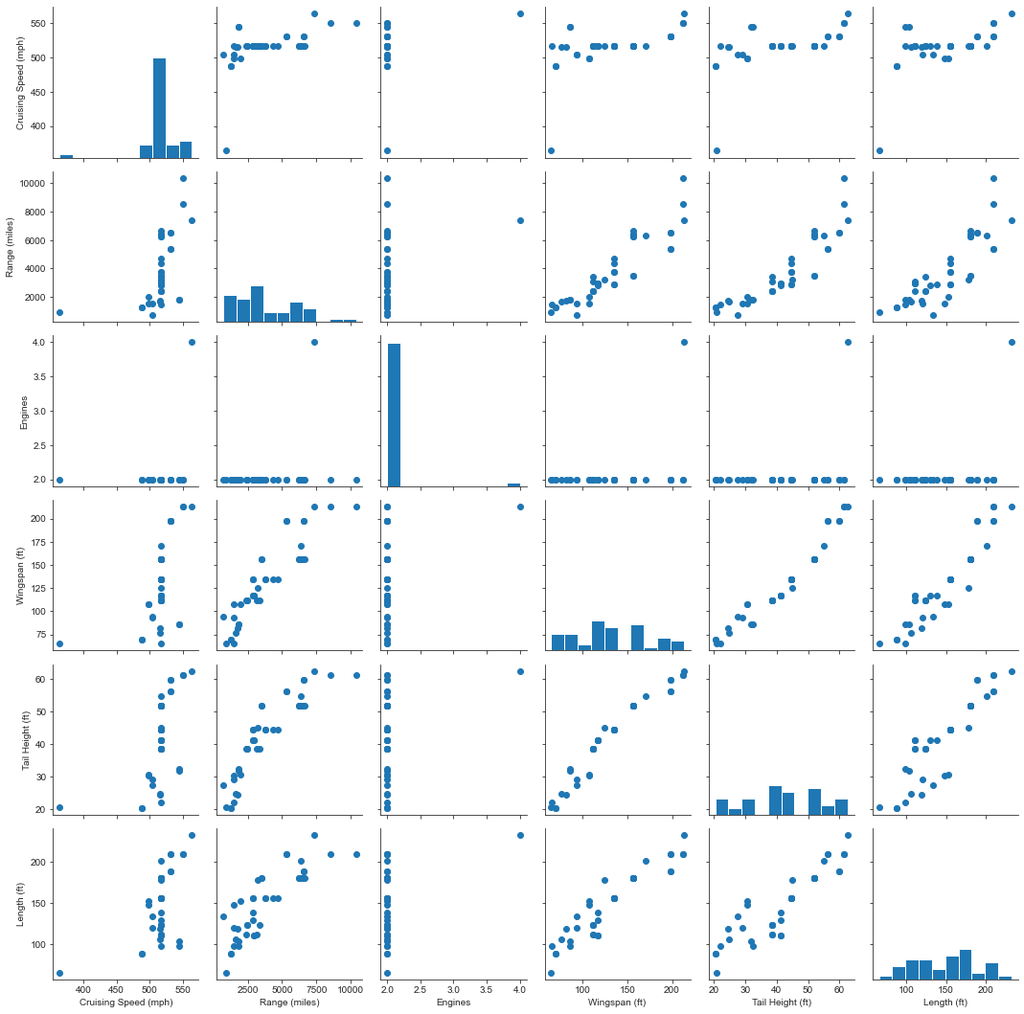

```python
pg = plot_pairgrid(df)
```

We observe that pretty strong positive correlations between all these variables, as most of them are related to the aircraft’s overall size. Remarkably there is an almost perfectly linear relationship between wingspan and tail height.

The exception here is engines. There is one outlier which has four engines, while all the other aircraft have two. In this way the engines variable is really more like a categorical variable, but we shall as the analysis progresses that this is not really important, as there are other variables which more strongly discern the aircraft from one another than this.

```python
### This is the unittest cell, please just run this cell without any modification once you generated "pg" above

cols = ['Cruising Speed (mph)', 'Range (miles)', 'Engines',
        'Wingspan (ft)', 'Tail Height (ft)', 'Length (ft)']

assert_is_instance(pg.fig, plt.Figure)
assert_equal(set(pg.data.columns), set(cols))

for ax in pg.diag_axes:
    assert_equal(len(ax.patches), 10)

for i, j in zip(*np.triu_indices_from(pg.axes, 1)):
    ax = pg.axes[i, j]
    x_in = df[cols[j]]
    y_in = df[cols[i]]
    x_out, y_out = ax.collections[0].get_offsets().T
    assert_array_equal(x_in, x_out)
    assert_array_equal(y_in, y_out)

for i, j in zip(*np.tril_indices_from(pg.axes, -1)):
    ax = pg.axes[i, j]
    x_in = df[cols[j]]
    y_in = df[cols[i]]
    x_out, y_out = ax.collections[0].get_offsets().T
    assert_array_equal(x_in, x_out)
    assert_array_equal(y_in, y_out)

for i, j in zip(*np.diag_indices_from(pg.axes)):
    ax = pg.axes[i, j]
    assert_equal(len(ax.collections), 0)
```

#### Apply PCA

I assume we dont know anything about dimensionality reduction techniques and just naively apply principle components to the data.

Write a function named fit_pca() that takes a pandas.DataFrame and uses [sklearn.decomposition.PCA](http://scikit-learn.org/stable/modules/generated/sklearn.decomposition.PCA.html) to fit a PCA model on all values of df.

```python
 def fit_pca(df, n_components):
    '''
    Uses sklearn.decomposition.PCA to fit a PCA model on "df".

    Parameters
    ----------
    df: A pandas.DataFrame. Comes from delta.csv.
    n_components: An int. Number of principal components to keep.

    Returns
    -------
    An sklearn.decomposition.pca.PCA instance.
    '''

    # YOUR CODE HERE

    #from sklearn.decomposition import PCA
    pca = PCA(n_components)
    pca.fit(df)

    return pca
```

```python
# we keep all components by setting n_components = no of cols in df. FYI df.shape[0] returns # of rows, len(df.columns) also works similar
pca_naive = fit_pca(df, n_components=df.shape[1])
```

```python
assert_is_instance(pca_naive, PCA)
assert_almost_equal(pca_naive.explained_variance_ratio_.sum(), 1.0, 3)
assert_equal(pca_naive.n_components_, df.shape[1])
assert_equal(pca_naive.whiten, False)
```

```python
def plot_naive_variance(pca):
    '''
    Plots the variance explained by each of the principal components.
    Attributes are not scaled, hence a naive approach.

    Parameters
    ----------
    pca: An sklearn.decomposition.pca.PCA instance.

    Returns
    -------
    A matplotlib.Axes instance.
    '''

    # YOUR CODE HERE
    fig, ax = plt.subplots(figsize=(10,6))

    # Decorate the plot
    ax.set_xlabel('Dimension #')
    ax.set_ylabel('Explained Variance Ratio')
    ax.set_title('Fraction of Explained Variance')
    ax.plot(pca.explained_variance_ratio_)


    return ax
```

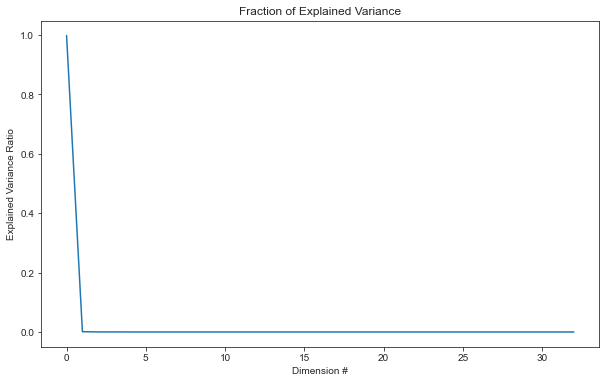

```python
naive_var = plot_naive_variance(pca_naive)
```

```python
assert_is_instance(naive_var, mpl.axes.Axes)
assert_equal(len(naive_var.lines), 1)

assert_is_not(len(naive_var.title.get_text()), 0,
    msg="Your plot doesn't have a title.")
assert_is_not(naive_var.xaxis.get_label_text(), '',
    msg="Change the x-axis label to something more descriptive.")
assert_is_not(naive_var.yaxis.get_label_text(), '',
    msg="Change the y-axis label to something more descriptive.")

xdata, ydata = naive_var.lines[0].get_xydata().T
assert_array_equal(xdata, list(range(df.shape[1])))
assert_array_almost_equal(ydata, pca_naive.explained_variance_ratio_)
```

```python
abs_val = np.abs(pca_naive.components_[0])
max_pos = abs_val.argmax()
max_val = abs_val.max()

print('"{0}" accounts for {1:0.3f} % of the variance.'.format(df.columns[max_pos], max_val))
```

```
"Range (miles)" accounts for 0.999 % of the variance.
```

PCA is a scale-dependent method. For example, if the range of one column is [-100, 100], while the that of another column is [-0.1, 0.1], PCA will place more weight on the feature with larger values. One way to avoid this is to standardize a data set by scaling each feature so that the individual features all look like Gausssian distributions with zero mean and unit variance.

Please write a function named standardize() where StandardScaler function of sklearn will be used to scale each feature so that they have zero mean and unit variance.

```python
def standardize(df):
    '''
    Uses sklearn.preprocessing.StandardScaler to make each features look like
    a Gaussian with zero mean and unit variance.

    Parameters
    ----------
    df: A pandas.DataFrame

    Returns
    -------
    A numpy array.
    '''

    # YOUR CODE HERE
    #from sklearn.preprocessing import StandardScaler
    scaler = StandardScaler()
    scaler.fit(df)
    scaled = scaler.transform(df)

    return scaled
```

```python
scaled = standardize(df)
```

```python
rng = np.random.RandomState(0)
n_samples, n_features = 4, 5

df_t1 = pd.DataFrame(
    rng.randn(n_samples, n_features),
    index=[i for i in 'abcd'],
    columns=[c for c  in 'abcde']
    )
df_t1.loc[:, 'a'] = 0.0  # make first feature zero

scaled_t1 = standardize(df_t1)

assert_is_not(df_t1, scaled_t1)
assert_is_instance(scaled_t1, np.ndarray)
assert_array_almost_equal(
    scaled_t1.mean(axis=0),
    n_features * [0.0] # scaled data should have mean zero
    )
assert_array_almost_equal(
    scaled_t1.std(axis=0),
    [0., 1., 1., 1., 1.] # unit variance except for 1st feature
    )
```

```python
# we keep only 10 components
n_components = 10
pca = fit_pca(scaled, n_components=n_components)
```

Let's take another look to the explained variance of the first 10 principal components from the scaled data.

```python
def plot_scaled_variance(pca):
    '''
    Plots the variance explained by each of the principal components.
    Features are scaled with sklearn.StandardScaler.

    Parameters
    ----------
    pca: An sklearn.decomposition.pca.PCA instance.

    Returns
    -------
    A matplotlib.Axes instance.
    '''

    # YOUR CODE HERE
    fig, ax = plt.subplots(figsize=(10,6))

    # Decorate the plot
    ax.set_xlabel('Dimension #')
    ax.set_ylabel('Explained Variance Ratio')
    ax.set_title('Fraction of Explained Variance')
    ax.plot(pca.explained_variance_ratio_)

    return ax
```

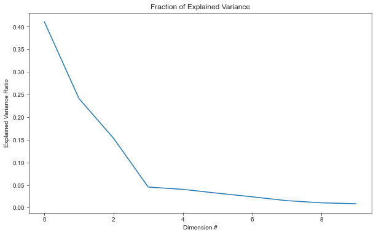

```python
ax = plot_scaled_variance(pca)
```

```python
assert_is_instance(ax, mpl.axes.Axes)
assert_equal(len(ax.lines), 1)

assert_is_not(len(ax.title.get_text()), 0, msg="Your plot doesn't have a title.")
assert_is_not(ax.xaxis.get_label_text(), '', msg="Change the x-axis label to something more descriptive.")
assert_is_not(ax.yaxis.get_label_text(), '', msg="Change the y-axis label to something more descriptive.")

xdata, ydata = ax.lines[0].get_xydata().T
assert_array_equal(xdata, list(range(n_components)))
assert_array_almost_equal(ydata, pca.explained_variance_ratio_)
```

Nice, it looks good to go. There are various rules of thumb for selecting the number of principal components to retain in an analysis of this type, one of which I’ve experienced about is:

Pick the number of components which explain 85% or greater of the variation. So, we will keep the first 4 principal components (remember that we are counting from zero, so we are keeping 0th, 1st, 2nd, and 3rd components—four components). Later in this assignment, we will use these four components to fit a $k$-means model. Before we move on to the next problem, let's apply the dimensional reduction on the scaled data. (In the previous sections, we didn't actually have to apply transform(). This step is to make sure that the scaled data is actually "transformed".)

Write a function named reduce() that takes a PCA model (that is already trained on array) and a Numpy array, and applies dimensional reduction on the array.

```python
def reduce(pca, array):
    '''
    Applies the `pca` model on array.

    Parameters
    ----------
    pca: An sklearn.decomposition.PCA instance.

    Returns
    -------
    A Numpy array
    '''

    # YOUR CODE HERE

    reduced = pca.transform(array)


    return reduced
```

```python
reduced = reduce(pca, scaled)
```

```python
assert_is_instance(reduced, np.ndarray)
assert_array_almost_equal(reduced, pca.fit_transform(scaled))
```

```python
# Save the reduced data to the same directory of your notebook  as 'delta_reeuced.npy' that we will use later on
np.save('delta_reduced.npy', reduced)
```

### Problem 2. Clustering

We will use the first 10 principal components of the Delta Airline data set that we created in the first step.

```python
##Standard imports just in case

%matplotlib inline

import numpy as np
import pandas as pd
import seaborn as sns
import matplotlib as mpl
import matplotlib.pyplot as plt
import sklearn

from sklearn.utils import check_random_state
from sklearn.cluster import KMeans

from nose.tools import assert_equal, assert_is_instance, assert_true, assert_is_not
from numpy.testing import assert_array_equal, assert_array_almost_equal, assert_almost_equal
```

```python
## Reload the the first 10 components of delta dataset
reduced = np.load('delta_reduced.npy')
```

Write a function named cluster() that fits a k-means clustering algorithm, and returns a tuple (sklearn.cluster.k*means*.KMeans, np.array). The second element of the tuple is a 1-d array that contains the predictions of k-means clustering, i.e. which cluster each data point belongs to. Please remember how we were generating and using the labels for seeds, movements, iris etc.

Use default values for all parameters in KMeans() execept for n_clusters and random_state.

```python
def cluster(array, random_state, n_clusters=4):
    '''
    Fits and predicts k-means clustering on "array"

    Parameters
    ----------
    array: A numpy array
    random_state: Random seed, e.g. check_random_state(0)
    n_clusters: The number of clusters. Default: 4

    Returns
    -------
    A tuple (sklearn.KMeans, np.ndarray)
    '''

    # YOUR CODE HERE
    model = KMeans(n_clusters = n_clusters, random_state = random_state)

    model.fit(array)

    clusters = model.predict(array)


    return model, clusters

#here we return fitted (model) and predicted (clusters) arrays as a tuple
```

```python
k_means_t, cluster_t = cluster(reduced, random_state=check_random_state(1), n_clusters=5)

assert_is_instance(k_means_t, sklearn.cluster._kmeans.KMeans)
assert_is_instance(cluster_t, np.ndarray)
assert_equal(k_means_t.n_init, 10)
assert_equal(k_means_t.n_clusters, 5)
assert_equal(len(cluster_t), len(reduced))
assert_true((cluster_t < 5).all()) # n_cluster = 5 so labels should be between 0 and 5
assert_true((cluster_t >= 0).all())
labels_gold = -1. * np.ones(len(reduced), dtype=np.int)
mindist = np.empty(len(reduced))
mindist.fill(np.infty)
for i in range(5):
    dist = np.sum((reduced - k_means_t.cluster_centers_[i])**2., axis=1)
    labels_gold[dist < mindist] = i
    mindist = np.minimum(dist, mindist)
assert_true((mindist >= 0.0).all())
assert_true((labels_gold != -1).all())
assert_array_equal(labels_gold, cluster_t)
```

The scikit-learn documentation on sklearn.cluster.KMeans says that [Kmeans cluster](http://scikit-learn.org/stable/modules/generated/sklearn.cluster.KMeans.html) has the inertia value in the inertia *attribute. So we can vary the number of clusters in KMeans, plot KMeans.inertia* as a function of the number of clusters, and pick the "elbow" in the plot.

Always use check_random_state(0) to seed the random number generator.

```python
def plot_inertia(array, start=1, end=10):
    '''
    Increase the number of clusters from "start" to "end" (inclusive).
    Finds the inertia of k-means clustering for different k.
    Plots inertia as a function of the number of clusters.


    Parameters
    ----------
    array: A numpy array.
    start: An int. Default: 1
    end: An int. Default: 10

    Returns
    -------
    A matplotlib.Axes instance.
    '''
    #Your code is here

    x_axis = range(start, end+1)
    inertia = []

    for k in x_axis:
        # Create a KMeans instance with k clusters: model
        model = KMeans(n_clusters=k, random_state = check_random_state(0))

        # Fit model to samples
        model.fit(array)

        # Append the inertia to the list of inertias
        inertia.append(model.inertia_)




    fig, ax = plt.subplots(figsize=(10,6))

    ax.set_title('The elbow method')
    ax.set_ylabel('Inertia', size=12)
    ax.set_xlabel('Number of clusters', size=12)
    plt.plot(x_axis, inertia)


    return ax
```

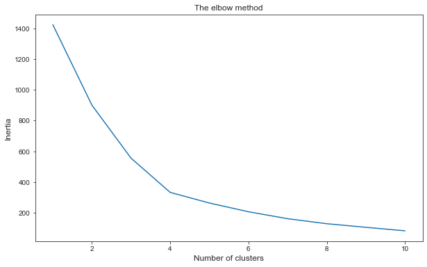

```python
inertia = plot_inertia(reduced)
```

```python
assert_is_instance(inertia, mpl.axes.Axes)
assert_true(len(inertia.lines) >= 1)

xdata, ydata = inertia.lines[0].get_xydata().T

for i in range(1, 11):
    k_means_t, cluster_t = cluster(reduced, random_state=check_random_state(0), n_clusters=i)
    assert_array_equal(xdata[i - 1], i)
    assert_almost_equal(ydata[i - 1], k_means_t.inertia_)

assert_is_not(len(inertia.title.get_text()), 0,
    msg="Your plot doesn't have a title.")
assert_is_not(inertia.xaxis.get_label_text(), '',
    msg="Change the x-axis label to something more descriptive.")
assert_is_not(inertia.yaxis.get_label_text(), '',
    msg="Change the y-axis label to something more descriptive.")
```

```python
def plot_pair(reduced, clusters):
    '''
    Uses seaborn.PairGrid to visualize the data distribution
    when axes are the first four principal components.
    Diagonal plots are histograms. The off-diagonal plots are scatter plots.

    Parameters
    ----------
    reduced: A numpy array. Comes from importing delta_reduced.npy

    Returns
    -------
    A seaborn.axisgrid.PairGrid instance.
    '''



    df = pd.DataFrame(reduced)
    df['c'] = clusters
    subset = [0,1,2,3, 'c']
    columns = [0,1,2,3]



    ax = sns.PairGrid(df[subset], vars = columns, hue = 'c')
    ax.map_diag(plt.hist)
    ax.map_offdiag(plt.scatter)


    return ax
```

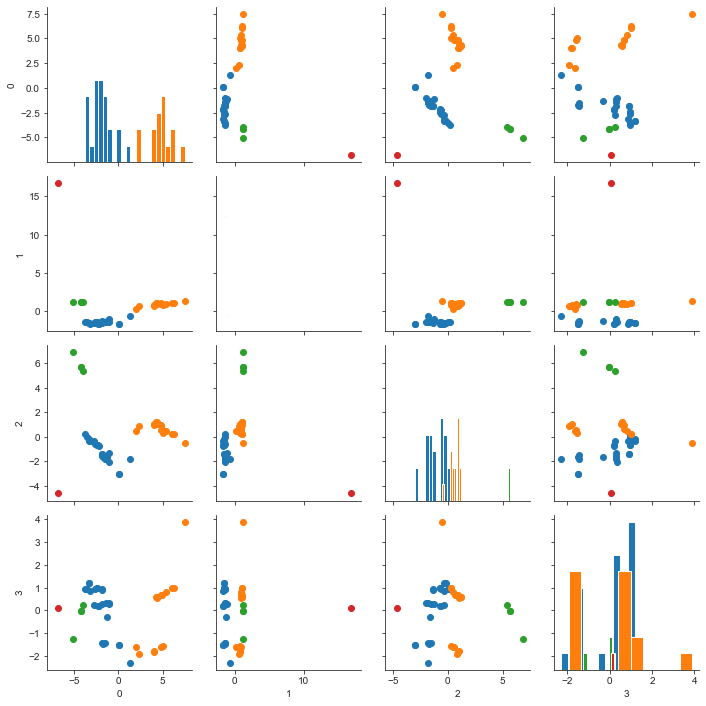

```python
k_means, clusters = cluster(reduced, random_state=check_random_state(0), n_clusters=4)
pg = plot_pair(reduced, clusters)
```

We observe that the one outlier is in its own cluster, there’s 3 or 4 points in the other clusters and the remainder are split into two clusters of greater size.

```python
assert_is_instance(pg.fig, plt.Figure)
assert_true(len(pg.data.columns) >= 4)

for ax in pg.diag_axes:
    assert_equal(len(ax.patches), 4 * 10) # 4 clusters with 10 patches in each histogram

for i, j in zip(*np.triu_indices_from(pg.axes, 1)):
    ax = pg.axes[i, j]
    x_out, y_out = ax.collections[0].get_offsets().T
    x_in = reduced[clusters == 0, j] # we only check the first cluster
    y_in = reduced[clusters == 0, i]
    assert_array_equal(x_in, x_out)
    assert_array_equal(y_in, y_out)

for i, j in zip(*np.tril_indices_from(pg.axes, -1)):
    ax = pg.axes[i, j]
    x_in = reduced[clusters == 0, j]
    y_in = reduced[clusters == 0, i]
    x_out, y_out = ax.collections[0].get_offsets().T
    assert_array_equal(x_in, x_out)
    assert_array_equal(y_in, y_out)

for i, j in zip(*np.diag_indices_from(pg.axes)):
    ax = pg.axes[i, j]
    assert_equal(len(ax.collections), 0)
```

#### Let's Continue our Analysis and brainstorm

You don't have to write any code in this section, but here's one interpretaion of what we have done.

Let's take a closer look at each cluster.

```python
df = pd.read_csv('delta.csv', index_col='Aircraft')
df['Clusters'] = clusters
df['Aircraft'] = df.index
df_grouped = df.groupby('Clusters').mean(numeric_only=True)
print(df_grouped.Accommodation)
```

```
Clusters
0    153.625000
1    244.733333
2     44.500000
3     54.000000
Name: Accommodation, dtype: float64
```

```python
print(df_grouped['Length (ft)'])
```

```
Clusters
0    137.048083
1    190.538400
2     84.810750
3    111.000000
Name: Length (ft), dtype: float64
```

Cluster 3 has only one aircraft:

```python
clust3 = df[df.Clusters == 3]
print(clust3.Aircraft)
```

```
Aircraft
Airbus A319 VIP    Airbus A319 VIP
Name: Aircraft, dtype: object
```

Airbus A319 VIP is not one of Delta Airline's regular fleet and is one of Airbus corporate jets.

Cluster 2 has four aircrafts.

```python
clust2 = df[df.Clusters == 2]
print(clust2.Aircraft)
```

```
Aircraft
CRJ 100/200 Pinnacle/SkyWest    CRJ 100/200 Pinnacle/SkyWest
CRJ 100/200 ExpressJet                CRJ 100/200 ExpressJet
E120                                                    E120
ERJ-145                                              ERJ-145
Name: Aircraft, dtype: object
```

These are small aircrafts and only have economy seats.

```python
cols_seat = ['First Class', 'Business', 'Eco Comfort', 'Economy']
print(df.loc[clust2.index, cols_seat])
```

```
                              First Class  Business  Eco Comfort  Economy
Aircraft
CRJ 100/200 Pinnacle/SkyWest            0         0            0        1
CRJ 100/200 ExpressJet                  0         0            0        1
E120                                    0         0            0        1
ERJ-145                                 0         0            0        1
```

```python
clust1 = df[df.Clusters == 1]
print(clust1.Aircraft)
```

```
Aircraft
Airbus A330-200                      Airbus A330-200
Airbus A330-200 (3L2)          Airbus A330-200 (3L2)
Airbus A330-200 (3L3)          Airbus A330-200 (3L3)
Airbus A330-300                      Airbus A330-300
Boeing 747-400 (74S)            Boeing 747-400 (74S)
Boeing 757-200 (75E)            Boeing 757-200 (75E)
Boeing 757-200 (75X)            Boeing 757-200 (75X)
Boeing 767-300 (76G)            Boeing 767-300 (76G)
Boeing 767-300 (76L)            Boeing 767-300 (76L)
Boeing 767-300 (76T)            Boeing 767-300 (76T)
Boeing 767-300 (76Z V.1)    Boeing 767-300 (76Z V.1)
Boeing 767-300 (76Z V.2)    Boeing 767-300 (76Z V.2)
Boeing 767-400 (76D)            Boeing 767-400 (76D)
Boeing 777-200ER                    Boeing 777-200ER
Boeing 777-200LR                    Boeing 777-200LR
Name: Aircraft, dtype: object
```

Interesting, Cluster 1 aircrafts do not have first class seating.

```python
print(df.loc[clust1.index, cols_seat])
```

```
                          First Class  Business  Eco Comfort  Economy
Aircraft
Airbus A330-200                     0         1            1        1
Airbus A330-200 (3L2)               0         1            1        1
Airbus A330-200 (3L3)               0         1            1        1
Airbus A330-300                     0         1            1        1
Boeing 747-400 (74S)                0         1            1        1
Boeing 757-200 (75E)                0         1            1        1
Boeing 757-200 (75X)                0         1            1        1
Boeing 767-300 (76G)                0         1            1        1
Boeing 767-300 (76L)                0         1            1        1
Boeing 767-300 (76T)                0         1            1        1
Boeing 767-300 (76Z V.1)            0         1            1        1
Boeing 767-300 (76Z V.2)            0         1            1        1
Boeing 767-400 (76D)                0         1            1        1
Boeing 777-200ER                    0         1            1        1
Boeing 777-200LR                    0         1            1        1
```

```python
clust0 = df[df.Clusters == 0]
print(clust0.Aircraft)
```

```
Aircraft
Airbus A319                          Airbus A319
Airbus A320                          Airbus A320
Airbus A320 32-R                Airbus A320 32-R
Boeing 717                            Boeing 717
Boeing 737-700 (73W)        Boeing 737-700 (73W)
Boeing 737-800 (738)        Boeing 737-800 (738)
Boeing 737-800 (73H)        Boeing 737-800 (73H)
Boeing 737-900ER (739)    Boeing 737-900ER (739)
Boeing 757-200 (75A)        Boeing 757-200 (75A)
Boeing 757-200 (75M)        Boeing 757-200 (75M)
Boeing 757-200 (75N)        Boeing 757-200 (75N)
Boeing 757-200 (757)        Boeing 757-200 (757)
Boeing 757-200 (75V)        Boeing 757-200 (75V)
Boeing 757-300                    Boeing 757-300
Boeing 767-300 (76P)        Boeing 767-300 (76P)
Boeing 767-300 (76Q)        Boeing 767-300 (76Q)
Boeing 767-300 (76U)        Boeing 767-300 (76U)
CRJ 700                                  CRJ 700
CRJ 900                                  CRJ 900
E170                                        E170
E175                                        E175
MD-88                                      MD-88
MD-90                                      MD-90
MD-DC9-50                              MD-DC9-50
Name: Aircraft, dtype: object
```

The aircrafts in cluster 0 (except for one aircraft) have first class seating but no business class.

```python
print(df.loc[clust0.index, cols_seat])
```

```
                        First Class  Business  Eco Comfort  Economy
Aircraft
Airbus A319                       1         0            1        1
Airbus A320                       1         0            1        1
Airbus A320 32-R                  1         0            1        1
Boeing 717                        1         0            1        1
Boeing 737-700 (73W)              1         0            1        1
Boeing 737-800 (738)              1         0            1        1
Boeing 737-800 (73H)              1         0            1        1
Boeing 737-900ER (739)            1         0            1        1
Boeing 757-200 (75A)              1         0            1        1
Boeing 757-200 (75M)              1         0            1        1
Boeing 757-200 (75N)              1         0            1        1
Boeing 757-200 (757)              1         0            1        1
Boeing 757-200 (75V)              1         0            1        1
Boeing 757-300                    1         0            1        1
Boeing 767-300 (76P)              1         0            1        1
Boeing 767-300 (76Q)              1         0            1        1
Boeing 767-300 (76U)              0         1            1        1
CRJ 700                           1         0            1        1
CRJ 900                           1         0            1        1
E170                              1         0            1        1
E175                              1         0            1        1
MD-88                             1         0            1        1
MD-90                             1         0            1        1
MD-DC9-50                         1         0            1        1
```

### Problem 3

(No Unit Tests in this portion)

Run DBSCAN on Iris.csv and compare/discuss the results with K-Means. Please submit your code and output, and write down 3-4 sentences that you observed from the results.

Run DBSCAN on Reduced_Delta dataset and compare/discuss the results with K-Means. Please submit your code and output, and write down 3-4 sentences that you observed from the results.

Run KMeans on movements.csv compare/discuss the results with DBSCAN and Hierarchical Clustering (Agglomerative). Please submit your code and output, and write down 3-4 sentences that you observed from the results

- Import necessary packages

```python
from sklearn.neighbors import NearestNeighbors
from sklearn.cluster import DBSCAN
from sklearn.cluster import AgglomerativeClustering
```

- Define a function named `plot_knn()` that help find a suitable value for the eps neighborhood for DBSCAN. (Look for the knee in the plot.)

```python
def plot_knn(array, n_neighbors = 5):


    nbrs = NearestNeighbors(n_neighbors = n_neighbors).fit(array)
    distances, indices = nbrs.kneighbors(array)
    sort_distances = np.sort(distances, axis=0)
    k_dist = sort_distances[:, n_neighbors-1]

    fig, ax = plt.subplots(figsize=(10,6))

    ax.set_ylabel("k-NN distance")
    ax.set_xlabel("Sorted observations")
    plt.plot(k_dist)

    return ax
```

- Define a function named `cluster_dbscan()` that fits DBSCAN clustering algorithm, and returns a tuple (sklearn.cluster._dbscan.DBSCAN, np.array)

```python
def cluster_dbscan(array, eps=0.5, min_samples=5):

    model = DBSCAN(eps = eps, min_samples = min_samples)
    clusters = model.fit_predict(array)
    n_cluster = len(set(clusters))

    return model, clusters, n_cluster
```

- Define a function named `cluster_agg()` that fits a Agglomerative clustering algorithm, and returns a tuple (sklearn.cluster.k*means*.KMeans, np.array)

```python
def cluster_agg(array, n_clusters = 2, affinity = 'euclidean', linkage = 'ward'):

    model = AgglomerativeClustering(n_clusters = n_clusters, affinity = affinity, linkage = linkage)
    clusters = model.fit_predict(array)

    return model, clusters
```

### 3.1 Run DBSCAN on Iris.csv and compare/discuss the results with K-Means

Please submit your code and output, and write down 3-4 sentences that you observed from the results.

```python
iris = pd.read_csv('../Data/Iris.csv')
```

```python
# iris.info()
features = iris.iloc[:, 1:5]
```

3.1.1 Run Kmeans on Iris dataset  
Use Elbow Method to help decide the number of cluster

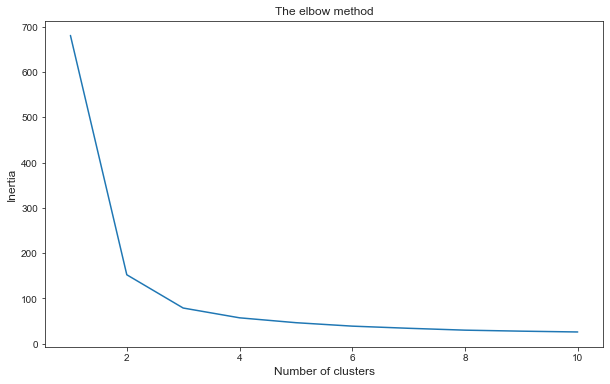

```python
plot_inertia(features, start=1, end=10)
```

**Run KMeans**  
Based on the plot above, n_clusters should be set to 3

```python
km_model, k_clusters = cluster(features, random_state=check_random_state(0), n_clusters=3)
```

3.1.2 Run DBSCAN on Iris dataset  
Use KNN to help decide the eps parameter

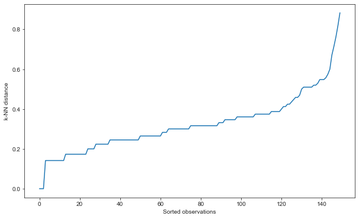

```python
plot_knn(features, n_neighbors = 3)
```

**Run DBSCAN**  
Based on the plot above, we can choose eps around 0.6

```python
db_model, db_clusters, n_clusters = cluster_dbscan(features, eps=0.6, min_samples=3)
print(f'There are {n_clusters} clusters.' )
```

```
There are 4 clusters.
```

**3.1.3 Compare the predictions**

**Set n_components=2 to fit PCA for making 2-D visualization**

```python
pca = fit_pca(features, n_components=2)
iris_2pc = pd.DataFrame(reduce(pca, features), columns = ['Feature1','Feature2'])
```

```python
iris_2pc['k_clusters'] = k_clusters
iris_2pc['db_clusters'] = db_clusters
iris_2pc['Species']= iris['Species']
```

```python
iris_2pc.head()
```

|  | Feature1 | Feature2 | k_clusters | db_clusters | Species |
| --- | --- | --- | --- | --- | --- |
| 0 | -2.684207 | 0.326607 | 1 | 0 | Iris-setosa |
| 1 | -2.715391 | -0.169557 | 1 | 0 | Iris-setosa |
| 2 | -2.889820 | -0.137346 | 1 | 0 | Iris-setosa |
| 3 | -2.746437 | -0.311124 | 1 | 0 | Iris-setosa |
| 4 | -2.728593 | 0.333925 | 1 | 0 | Iris-setosa |

Make the plot to visualize the difference.

```python
# Two sets of colors, can modify these to ensure colors match between known and predicted clusters.
clr = [sns.xkcd_rgb["light red"], sns.xkcd_rgb["light blue"], sns.xkcd_rgb["light green"]]
db_pclr = [sns.xkcd_rgb["light red"], sns.xkcd_rgb["light blue"], sns.xkcd_rgb["light green"], sns.xkcd_rgb["light yellow"]]
km_pclr = [sns.xkcd_rgb["light blue"], sns.xkcd_rgb["light red"], sns.xkcd_rgb["light green"]]

# Label data
lbls = ['Setosa', 'Versicolor', 'Virginica']
species = ['Iris-setosa', 'Iris-versicolor', 'Iris-virginica']
db_plbls = ['DB-Class 0', 'DB-Class 1', 'DB-Class 2', 'outlier']
km_plbls = ['KM-Class 0', 'KM-Class 1', 'KM-Class 2']
cols = ['Feature1', 'Feature2', 'Species']
```

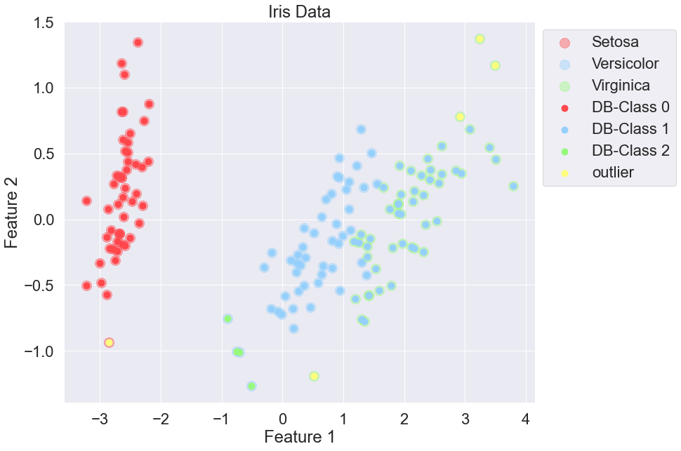

```python
sns.set(font_scale=2.0)
fig, ax = plt.subplots(figsize=(12, 10))

for idx in range(3):

    tmp_df = iris_2pc[iris_2pc['Species'] == species[idx]]
    ax.scatter(tmp_df['Feature1'], tmp_df['Feature2'], color=clr[idx], label=lbls[idx], alpha=0.4, s=200)

for label in [0,1,2,-1]:

    tmp_pdf = iris_2pc[iris_2pc['db_clusters'] == label]
    ax.scatter(tmp_pdf['Feature1'], tmp_pdf['Feature2'], color=db_pclr[label], label=db_plbls[label], alpha=1, s=80)


ax.set_xlabel('Feature 1')
ax.set_ylabel('Feature 2')
ax.set_title('Iris Data')
ax.legend(bbox_to_anchor=(1.0, 1), loc=2)

sns.despine(offset=5, trim=True)
sns.set(font_scale=1.0)
```

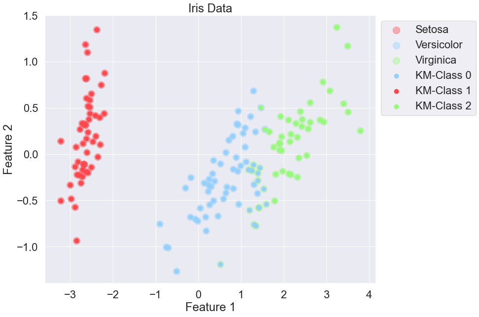

```python
sns.set(font_scale=2.0)
fig, ax = plt.subplots(figsize=(12, 10))

for idx in range(3):

    tmp_df = iris_2pc[iris_2pc['Species'] == species[idx]]
    ax.scatter(tmp_df['Feature1'], tmp_df['Feature2'], color=clr[idx], label=lbls[idx], alpha=0.4, s=200)


for label in range(3):

    tmp_pdf = iris_2pc[iris_2pc['k_clusters'] == label]
    ax.scatter(tmp_pdf['Feature1'], tmp_pdf['Feature2'], color=km_pclr[label], label=km_plbls[label], alpha=1, s=80)



ax.set_xlabel('Feature 1')
ax.set_ylabel('Feature 2')
ax.set_title('Iris Data')
ax.legend(bbox_to_anchor=(1.0, 1), loc=2)

sns.despine(offset=5, trim=True)
sns.set(font_scale=1.0)
```

Make the crosstab between actual label and clusters created using KMeans and DBSCAN.

```python
ct_species_kmeans = pd.crosstab(iris_2pc['Species'], iris_2pc['k_clusters'])
ct_species_dbscan = pd.crosstab(iris_2pc['Species'], iris_2pc['db_clusters'])

# Display ct
print(f'The crosstab of the species and the prediction using KMeans is : \n {ct_species_kmeans} \n')
print(f'The crosstab of the species and the prediction using DBSCAN is : \n {ct_species_dbscan} \n')
```

```
The crosstab of the species and the prediction using KMeans is :
 k_clusters        0   1   2
Species
Iris-setosa       0  50   0
Iris-versicolor  48   0   2
Iris-virginica   14   0  36

The crosstab of the species and the prediction using DBSCAN is :
 db_clusters      -1   0   1   2
Species
Iris-setosa       1  49   0   0
Iris-versicolor   0   0  46   4
Iris-virginica    4   0  46   0
```

**3.1.4 Interpretation: DBSCAN vs KMeans (Iris dataset)**

Based on the scatterplot and crosstab, we can see that both clustering algorithm do a pretty good job in identifying **Setosa** while struggle with telling **Versicolor** and **Virginica** apart, with KMeans putting 14 virginica and 48 versicolor in one cluster, and DBSCAN putting 46 virginica and 46 versicolor in one cluster. In addition, DBSCAN also classifies 5 datapoints as noise (outlier) whereas KMeans puts them in the correct cluster mostly.  
In conclusion, KMeans works better with Iris dataset comparing to DBSCAN (density based), which doesn't function well because there isn't too much of a drop in density between different clusters.

### 3.2 Run DBSCAN on Reduced_Delta dataset and compare/discuss the results with K-Means

Please submit your code and output, and write down 3-4 sentences that you observed from the results.

```python
reduced_delta = np.load('delta_reduced.npy')
reduced = pd.DataFrame(reduced_delta)
```

3.2.1 Run Kmeans on Reduced_Delta dataset  
Use the Elbow Method to help decide the number of cluster

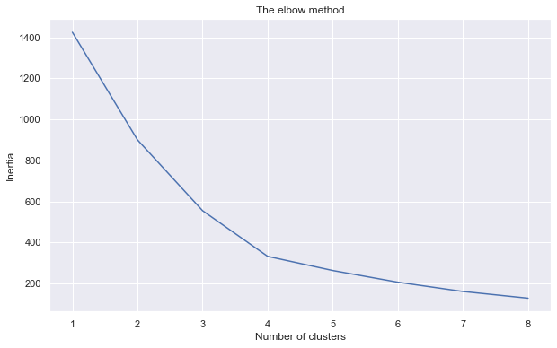

```python
plot_inertia(reduced, start=1, end=8)
```

**Run KMeans**  
Based on the plot above, n_clusters should be set to 4

```python
km_model, k_clusters = cluster(reduced, random_state=check_random_state(0), n_clusters=4)
```

3.2.2 Run DBSCAN on Reduced_Delta dataset  
Use KNN to help decide the eps parameter

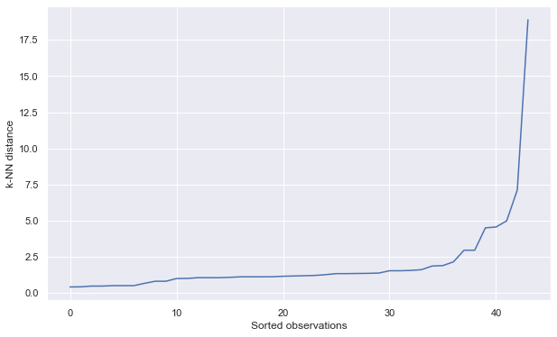

```python
plot_knn(reduced, n_neighbors = 3)
```

**Run dbscan**  
Based on the plot above, we can choose eps around 3

```python
db_model, db_clusters, n_clusters = cluster_dbscan(reduced, eps=3, min_samples=3)
print(f'There are {n_clusters} clusters.' )
```

```
There are 5 clusters.
```

**3.2.3 Compare the predictions**

```python
delta = pd.read_csv('delta.csv', index_col='Aircraft')
delta['Aircraft'] = delta.index
delta['k_clusters'] = k_clusters
delta['db_clusters'] = db_clusters
```

```python
pd.set_option('display.max_columns', None)
delta_groupby_km = delta.groupby('k_clusters').mean(numeric_only=True)
delta_groupby_db = delta.groupby('db_clusters').mean(numeric_only=True)
```

```python
ct = pd.crosstab(delta['k_clusters'], delta['db_clusters'])
print(ct)
```

```
db_clusters  -1   0   1   2   3
k_clusters
0             1  23   0   0   0
1             2   0   8   5   0
2             1   0   0   0   3
3             1   0   0   0   0
```

```python
delta.columns
```

```
Index(['Seat Width (Club)', 'Seat Pitch (Club)', 'Seat (Club)',
       'Seat Width (First Class)', 'Seat Pitch (First Class)',
       'Seats (First Class)', 'Seat Width (Business)', 'Seat Pitch (Business)',
       'Seats (Business)', 'Seat Width (Eco Comfort)',
       'Seat Pitch (Eco Comfort)', 'Seats (Eco Comfort)',
       'Seat Width (Economy)', 'Seat Pitch (Economy)', 'Seats (Economy)',
       'Accommodation', 'Cruising Speed (mph)', 'Range (miles)', 'Engines',
       'Wingspan (ft)', 'Tail Height (ft)', 'Length (ft)', 'Wifi', 'Video',
       'Power', 'Satellite', 'Flat-bed', 'Sleeper', 'Club', 'First Class',
       'Business', 'Eco Comfort', 'Economy', 'Aircraft', 'k_clusters',
       'db_clusters'],
      dtype='object')
```

```python
# Compare Accomodations (Total Seats)
print(delta_groupby_km.Accommodation)
print(delta_groupby_db.Accommodation)
```

```
k_clusters
0    153.625000
1    244.733333
2     44.500000
3     54.000000
Name: Accommodation, dtype: float64
db_clusters
-1    170.400000
 0    151.173913
 1    245.625000
 2    229.200000
 3     50.000000
Name: Accommodation, dtype: float64
```

```python
# Length (ft)
print(delta_groupby_km['Length (ft)'])
print(delta_groupby_db['Length (ft)'])
```

```
k_clusters
0    137.048083
1    190.538400
2     84.810750
3    111.000000
Name: Length (ft), dtype: float64
db_clusters
-1    148.782600
 0    135.169739
 1    194.718250
 2    182.650000
 3     91.220000
Name: Length (ft), dtype: float64
```

```python
cols_seat = ['First Class', 'Business', 'Eco Comfort', 'Economy']
print('K-Means Clustering \n')
for i in range(4):
    print(f'KM-Cluster {i} aircraft types:')
    clust = delta[delta.k_clusters == i]
    #print(clust.k_clusters)
    print(delta.loc[clust.index, cols_seat])
    print('\n')
```

```
K-Means Clustering

KM-Cluster 0 aircraft types:
                        First Class  Business  Eco Comfort  Economy
Aircraft
Airbus A319                       1         0            1        1
Airbus A320                       1         0            1        1
Airbus A320 32-R                  1         0            1        1
Boeing 717                        1         0            1        1
Boeing 737-700 (73W)              1         0            1        1
Boeing 737-800 (738)              1         0            1        1
Boeing 737-800 (73H)              1         0            1        1
Boeing 737-900ER (739)            1         0            1        1
Boeing 757-200 (75A)              1         0            1        1
Boeing 757-200 (75M)              1         0            1        1
Boeing 757-200 (75N)              1         0            1        1
Boeing 757-200 (757)              1         0            1        1
Boeing 757-200 (75V)              1         0            1        1
Boeing 757-300                    1         0            1        1
Boeing 767-300 (76P)              1         0            1        1
Boeing 767-300 (76Q)              1         0            1        1
Boeing 767-300 (76U)              0         1            1        1
CRJ 700                           1         0            1        1
CRJ 900                           1         0            1        1
E170                              1         0            1        1
E175                              1         0            1        1
MD-88                             1         0            1        1
MD-90                             1         0            1        1
MD-DC9-50                         1         0            1        1


KM-Cluster 1 aircraft types:
                          First Class  Business  Eco Comfort  Economy
Aircraft
Airbus A330-200                     0         1            1        1
Airbus A330-200 (3L2)               0         1            1        1
Airbus A330-200 (3L3)               0         1            1        1
Airbus A330-300                     0         1            1        1
Boeing 747-400 (74S)                0         1            1        1
Boeing 757-200 (75E)                0         1            1        1
```

[output cut: 9 more lines]

```


KM-Cluster 2 aircraft types:
                              First Class  Business  Eco Comfort  Economy
Aircraft
CRJ 100/200 Pinnacle/SkyWest            0         0            0        1
CRJ 100/200 ExpressJet                  0         0            0        1
E120                                    0         0            0        1
ERJ-145                                 0         0            0        1


KM-Cluster 3 aircraft types:
                 First Class  Business  Eco Comfort  Economy
Aircraft
Airbus A319 VIP            1         1            0        0
```

```python
cols_seat = ['First Class', 'Business', 'Eco Comfort', 'Economy']
print('DBSCAN Clustering \n')
for i in [0,1,2,3,-1]:
    print(f'DB-Cluster {i} aircraft types:')
    clust = delta[delta.db_clusters == i]
    #print(clust.k_clusters)
    print(delta.loc[clust.index, cols_seat])
    print('\n')
```

```
DBSCAN Clustering

DB-Cluster 0 aircraft types:
                        First Class  Business  Eco Comfort  Economy
Aircraft
Airbus A319                       1         0            1        1
Airbus A320                       1         0            1        1
Airbus A320 32-R                  1         0            1        1
Boeing 717                        1         0            1        1
Boeing 737-700 (73W)              1         0            1        1
Boeing 737-800 (738)              1         0            1        1
Boeing 737-800 (73H)              1         0            1        1
Boeing 737-900ER (739)            1         0            1        1
Boeing 757-200 (75A)              1         0            1        1
Boeing 757-200 (75M)              1         0            1        1
Boeing 757-200 (75N)              1         0            1        1
Boeing 757-200 (757)              1         0            1        1
Boeing 757-200 (75V)              1         0            1        1
Boeing 757-300                    1         0            1        1
Boeing 767-300 (76P)              1         0            1        1
Boeing 767-300 (76Q)              1         0            1        1
CRJ 700                           1         0            1        1
CRJ 900                           1         0            1        1
E170                              1         0            1        1
E175                              1         0            1        1
MD-88                             1         0            1        1
MD-90                             1         0            1        1
MD-DC9-50                         1         0            1        1


DB-Cluster 1 aircraft types:
                          First Class  Business  Eco Comfort  Economy
Aircraft
Airbus A330-200                     0         1            1        1
Airbus A330-200 (3L3)               0         1            1        1
Boeing 767-300 (76L)                0         1            1        1
Boeing 767-300 (76T)                0         1            1        1
Boeing 767-300 (76Z V.1)            0         1            1        1
Boeing 767-400 (76D)                0         1            1        1
Boeing 777-200ER                    0         1            1        1
```

[output cut: 14 more lines]

```
                              First Class  Business  Eco Comfort  Economy
Aircraft
CRJ 100/200 Pinnacle/SkyWest            0         0            0        1
CRJ 100/200 ExpressJet                  0         0            0        1
ERJ-145                                 0         0            0        1


DB-Cluster -1 aircraft types:
                      First Class  Business  Eco Comfort  Economy
Aircraft
Airbus A319 VIP                 1         1            0        0
Boeing 747-400 (74S)            0         1            1        1
Boeing 757-200 (75X)            0         1            1        1
Boeing 767-300 (76U)            0         1            1        1
E120                            0         0            0        1
```

**Set n_components=2 to fit PCA for making 2-D visualization**

```python
pca = fit_pca(reduced, n_components=2)
delta_2pc = pd.DataFrame(reduce(pca, reduced), columns = ['Feature1','Feature2'])
delta_2pc['k_clusters'] = k_clusters
delta_2pc['db_clusters'] = db_clusters
delta_2pc.head()
```

|  | Feature1 | Feature2 | k_clusters | db_clusters |
| --- | --- | --- | --- | --- |
| 0 | -2.656021 | -1.382411 | 0 | 0 |
| 1 | -6.766622 | 16.743734 | 3 | -1 |
| 2 | -2.396654 | -1.487692 | 0 | 0 |
| 3 | -2.396654 | -1.487692 | 0 | 0 |
| 4 | 4.862387 | 0.951892 | 1 | 1 |

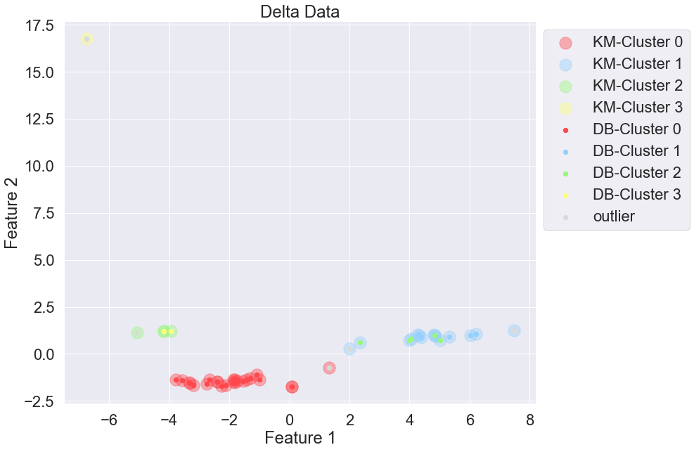

```python
# Two sets of colors, can modify these to ensure colors match between known and predicted clusters.
db_pclr = [sns.xkcd_rgb["light red"], sns.xkcd_rgb["light blue"], sns.xkcd_rgb["light green"], sns.xkcd_rgb["light yellow"], sns.xkcd_rgb["light grey"]]
km_pclr = [sns.xkcd_rgb["light red"], sns.xkcd_rgb["light blue"], sns.xkcd_rgb["light green"], sns.xkcd_rgb["light yellow"]]

# Label data
db_plbls = ['DB-Cluster 0', 'DB-Cluster 1', 'DB-Cluster 2', 'DB-Cluster 3', 'outlier']
km_plbls = ['KM-Cluster 0', 'KM-Cluster 1', 'KM-Cluster 2', 'KM-Cluster 3']

sns.set(font_scale=2.0)
fig, ax = plt.subplots(figsize=(12, 10))


for label in range(4):

    tmp_pdf = delta_2pc[delta_2pc['k_clusters'] == label]
    ax.scatter(tmp_pdf['Feature1'], tmp_pdf['Feature2'], color=km_pclr[label], label=km_plbls[label], alpha=0.4, s=300)

for label in [0,1,2,3,-1]:

    tmp_pdf = delta_2pc[delta_2pc['db_clusters'] == label]
    ax.scatter(tmp_pdf['Feature1'], tmp_pdf['Feature2'], color=db_pclr[label], label=db_plbls[label], alpha=1, s=40)



ax.set_xlabel('Feature 1')
ax.set_ylabel('Feature 2')
ax.set_title('Delta Data')
ax.legend(bbox_to_anchor=(1.0, 1), loc=2)

sns.despine(offset=5, trim=True)
sns.set(font_scale=1.0)
```

**3.2.4 Interpretation: DBSCAN vs KMeans (Reduced_Delta dataset)**

Based on the crosstab, the analysis on different class combination, and the plot above, we can observe that:

1. DBSCAN automatically detects outliers and excludes them from all clusters, whereas K-Means tries its best to put each datapoint into one cluster without considering outliers.
2. Besides outlier, the major difference between DBSCAN clusters and K-Means clusters exists in KM-Cluster 1, which is basically further divided into two clusters, DB-Cluster 1 and DB-Cluster 2.
3. KM-Cluster 0 and 2 is similar to DB-Cluster 0 and 3 respectively, KM-Cluster 3 is outlier in DBSCAN.
4. The different class combination has a strong impact on both clustering, we can observe identical class combination in each clusters (except for one in KM-Cluster 0, and datapoints in DBSCAN outlier)
5. Both clustering techniques are quite suitable for Reduced-Delta dataset.

### 3.3 Run KMeans on movements.csv compare/discuss the results with DBSCAN & Agglomerative Clustering.

Please submit your code and output, and write down 3-4 sentences that you observed from the results

```python
movements = pd.read_csv("../Data/movements.csv", header=None, index_col=False, skiprows=1, usecols=range(1,964))
movements.head()
```

|  | 1 | 2 | 3 | 4 | 5 | 6 | 7 | 8 | 9 | 10 | 11 | 12 | 13 | 14 | 15 | 16 | 17 | 18 | 19 | 20 | 21 | 22 | 23 | 24 | 25 | 26 | 27 | 28 | 29 | … |
| --- | --- | --- | --- | --- | --- | --- | --- | --- | --- | --- | --- | --- | --- | --- | --- | --- | --- | --- | --- | --- | --- | --- | --- | --- | --- | --- | --- | --- | --- | --- |
| 0 | 0.580000 | -0.220005 | -3.409998 | -1.170000 | 1.680011 | -2.689994 | -1.469994 | 2.779997 | -0.680003 | -4.999995 | 6.709993 | -3.180006 | -4.009998 | -9.030006 | 0.560000 | -0.010000 | 1.030010 | -5.640009 | -9.019993 | 2.360001 | -0.050001 | 4.060000 | -4.680000 | 2.829998 | -1.570009 | -0.229992 | -0.769990 | 3.789993 | 2.269998 | … |
| 1 | -0.640002 | -0.650000 | -0.210001 | -0.420000 | 0.710001 | -0.200001 | -1.130001 | 0.069999 | -0.119999 | -0.500000 | 0.200001 | -0.100000 | -0.460001 | -1.190001 | -0.650000 | -1.300001 | 0.430000 | -1.690000 | -0.300001 | -0.420000 | -0.020001 | -0.099998 | -0.940001 | -0.090000 | -0.250000 | 0.760000 | 3.710001 | -0.200001 | 1.000000 | … |
| 2 | -2.350006 | 1.260009 | -2.350006 | -2.009995 | 2.960006 | -2.309997 | -1.640007 | 1.209999 | -1.790001 | -2.039994 | 1.300003 | -1.349998 | -0.639999 | -4.169998 | -1.790000 | -1.079995 | 1.720001 | 1.599999 | -4.360000 | -4.309997 | -0.669998 | 1.979995 | -2.699997 | 1.510002 | -2.549995 | -0.169998 | -0.639999 | 2.879997 | 0.670006 | … |
| 3 | 0.109997 | 0.000000 | 0.260002 | 0.720002 | 0.190003 | -0.270001 | 0.750000 | 0.300004 | 0.639999 | -0.130001 | 0.719997 | 0.050000 | -0.830002 | -2.770001 | -1.309997 | 0.559997 | 0.709999 | -1.239998 | 0.060002 | 0.369999 | 0.340000 | -0.579998 | -0.500000 | 0.189998 | -0.969997 | 0.270001 | 0.169998 | 0.480000 | 0.629997 | … |
| 4 | 0.459999 | 1.770000 | 1.549999 | 2.690003 | 0.059997 | -1.080002 | 0.360000 | 0.549999 | 0.530002 | -0.709999 | 0.050004 | -0.130001 | -1.099998 | -0.849999 | -0.569999 | 0.169998 | 3.090000 | 0.409999 | -2.200001 | 0.959999 | 0.649998 | -0.060001 | -1.630001 | -0.809997 | -0.440003 | 1.120003 | -0.169998 | 0.840000 | -0.219997 | … |

```python
movements.shape
```

```
(60, 963)
```

**Use standard scaler to transform data**

Since there are 963 features in this dataset, it's important to normalize or standardize it so that our model isn't affected by larger variances in certain columns.

```python
stdscaled_movements = standardize(movements)
```

Load company name (our label in this case) in a different dataset.

```python
companies = pd.read_csv("../Data/movements.csv", header=None, index_col=False, skiprows=1, usecols=[0])
companies.head(10)
```

|  | 0 |
| --- | --- |
| 0 | Apple |
| 1 | AIG |
| 2 | Amazon |
| 3 | American express |
| 4 | Boeing |
| 5 | Bank of America |
| 6 | British American Tobacco |
| 7 | Canon |
| 8 | Caterpillar |
| 9 | Colgate-Palmolive |

3.3.1 Run Kmeans on Movements dataset  
Use Elbow Method to help decide the number of cluster

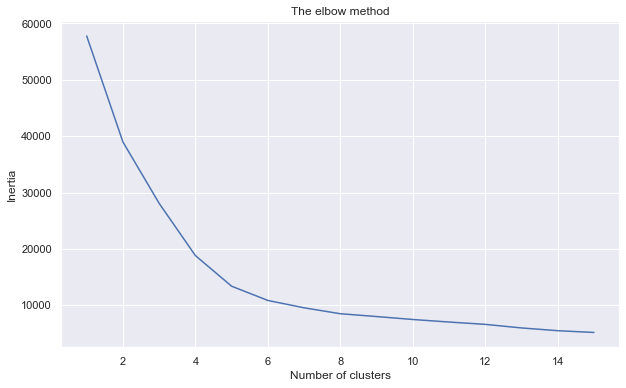

```python
plot_inertia(stdscaled_movements, start=1, end=15)
```

**Run KMeans**  
Based on the plot above, n_clusters should be set to 4 or 5

```python
km_model, k_clusters = cluster(stdscaled_movements, random_state=check_random_state(0), n_clusters=5)
```

```python
k_clusters
```

```
array([2, 1, 4, 1, 1, 1, 1, 1, 1, 1, 1, 1, 1, 1, 1, 1, 1, 0, 1, 1, 1, 1,
       1, 1, 1, 1, 1, 1, 1, 1, 3, 1, 1, 1, 1, 1, 1, 1, 1, 1, 1, 1, 1, 1,
       1, 1, 1, 1, 1, 1, 1, 1, 1, 1, 1, 1, 1, 1, 1, 1], dtype=int32)
```

3.3.2 Run DBSCAN on Movements dataset  
Use KNN to help decide the eps parameter

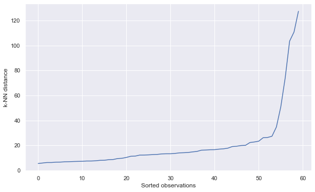

```python
plot_knn(stdscaled_movements, n_neighbors = 5)
```

**Run DBSCAN**  
Based on the plot above, we can choose eps around 30

```python
db_model, db_clusters, n_clusters = cluster_dbscan(stdscaled_movements, eps=30, min_samples=5)
print(f'There are {n_clusters} clusters.' )
```

```
There are 2 clusters.
```

```python
db_clusters
```

```
array([-1,  0, -1,  0,  0,  0,  0,  0,  0,  0,  0,  0,  0,  0,  0,  0,  0,
       -1, -1,  0,  0,  0,  0, -1,  0,  0,  0,  0,  0,  0, -1,  0,  0,  0,
        0,  0,  0,  0,  0,  0,  0,  0,  0,  0,  0,  0,  0,  0,  0,  0,  0,
        0,  0,  0,  0,  0,  0,  0,  0,  0])
```

**3.3.3 Run Agglomerative Clustering on Movements dataset**

```python
agg_model, agg_clusters = cluster_agg(stdscaled_movements, n_clusters = 5, affinity = 'euclidean', linkage = 'ward')
```

**3.3.4 Compare the predictions**

```python
companies['k_clusters'] = k_clusters
companies['db_clusters'] = db_clusters
companies['agg_clusters'] = agg_clusters
```

```python
companies.head()
```

|  | 0 | k_clusters | db_clusters | agg_clusters |
| --- | --- | --- | --- | --- |
| 0 | Apple | 2 | -1 | 3 |
| 1 | AIG | 1 | 0 | 0 |
| 2 | Amazon | 4 | -1 | 4 |
| 3 | American express | 1 | 0 | 0 |
| 4 | Boeing | 1 | 0 | 0 |

**Apply t-sne for visualization**

```python
from sklearn.manifold import TSNE
def fit_tsne(df, n_components = 2, learning_rate = 100):

    model = TSNE(n_components = n_components, learning_rate = learning_rate)
    reduced = model.fit_transform(df)

    return model, reduced
```

```python
# Apply fit_transform to normalized_movements: tsne_features
tsne, t_reduced = fit_tsne(stdscaled_movements, learning_rate = 100)

# Select the 0th feature: xs
companies['Feature1'] = t_reduced[:,0]

# Select the 1th feature: ys
companies['Feature2'] = t_reduced[:,1]
```

```python
# Set color
pclr = ['lightcoral','blue', 'gold', 'orange', 'olive']

# Label data
db_plbls = ['DB-Cluster 0', 'outlier']
km_plbls = ['KM-Cluster 0', 'KM-Cluster 1', 'KM-Cluster 2', 'KM-Cluster 3', 'KM-Cluster 4']
agg_plbls = ['AGG-Cluster 0', 'AGG-Cluster 1', 'AGG-Cluster 2', 'AGG-Cluster 3', 'AGG-Cluster 4']
```

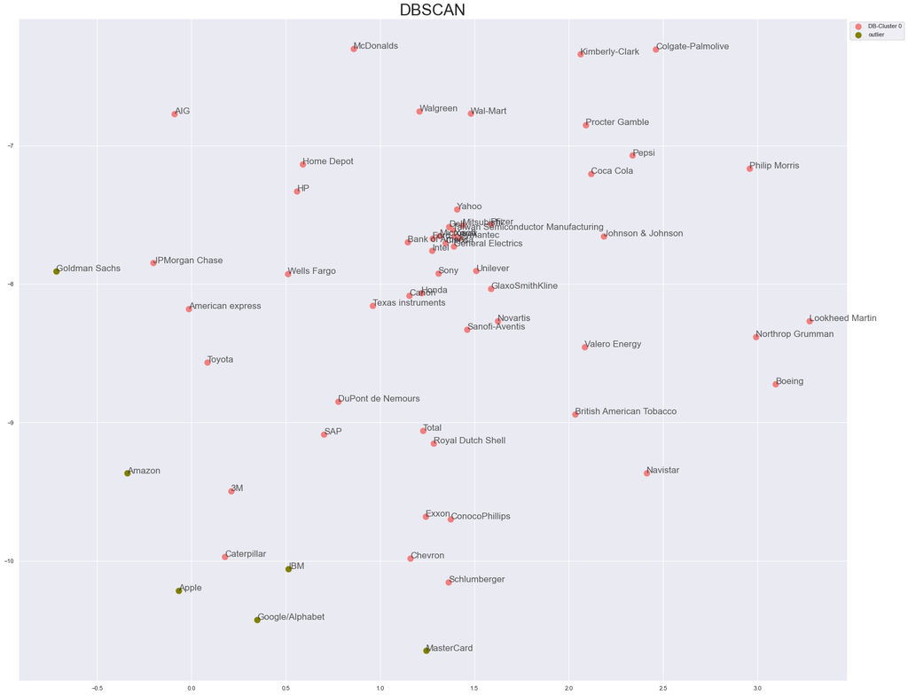

```python
plt.figure(figsize=(28,23))


# Scatter plot
for label in [0,-1]:
    tmp_pdf = companies[companies['db_clusters'] == label]
    plt.scatter(tmp_pdf['Feature1'], tmp_pdf['Feature2'], c=pclr[label], label=db_plbls[label], alpha=1, s=120)


# Annotate the points
for x, y, company in zip(companies['Feature1'], companies['Feature2'], companies[0]):
    plt.annotate(company, (x, y), fontsize=17, alpha=0.75)

plt.title("DBSCAN", size=30)
plt.legend(bbox_to_anchor=(1.0, 1), loc=2)
plt.show()
```

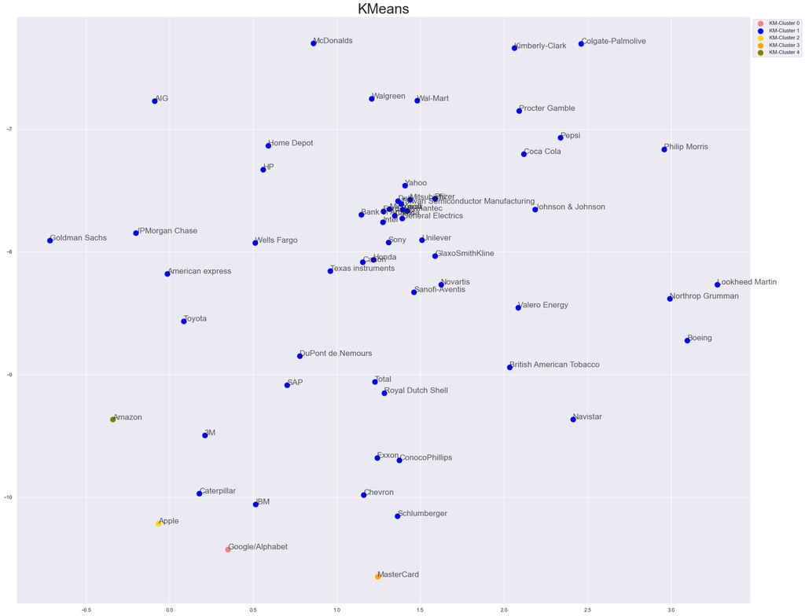

```python
plt.figure(figsize=(28,23))


# Scatter plot
for label in range(5):
    tmp_pdf = companies[companies['k_clusters'] == label]
    plt.scatter(tmp_pdf['Feature1'], tmp_pdf['Feature2'], c=pclr[label], label=km_plbls[label], alpha=1, s=120)


# Annotate the points
for x, y, company in zip(companies['Feature1'], companies['Feature2'], companies[0]):
    plt.annotate(company, (x, y), fontsize=17, alpha=0.75)

plt.title("KMeans", size=30)
plt.legend(bbox_to_anchor=(1.0, 1), loc=2)
plt.show()
```

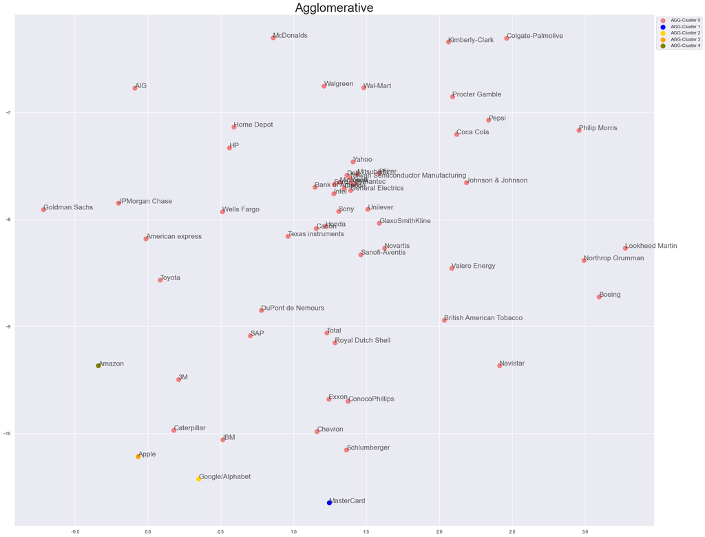

```python
plt.figure(figsize=(28,23))


# Scatter plot
for label in range(5):
    tmp_pdf = companies[companies['agg_clusters'] == label]
    plt.scatter(tmp_pdf['Feature1'], tmp_pdf['Feature2'], c=pclr[label], label=agg_plbls[label], alpha=1, s=120)


# Annotate the points
for x, y, company in zip(companies['Feature1'], companies['Feature2'], companies[0]):
    plt.annotate(company, (x, y), fontsize=17, alpha=0.75)

plt.title("Agglomerative", size=30)
plt.legend(bbox_to_anchor=(1.0, 1), loc=2)
plt.show()
```

**3.1.4 Interpretation: KMeans vs DBSCAN vs Agglomerative Clustering (Movements dataset)**

All three plots above show that running clustering algorithms on dataset with overwhelmingly many columns without applying dimension reduction first will end up in bad clustering and wasting time. The clustering among these three algorithms are very similar, except for a few datapoints (ex. Amazon, Google, Apple, Mastercard), which are outliers in DBSCAN but are each put in individual clusters in both K-Means and Agglomerative)

### Problem 4

Apply t-SNE reduction to delta.csv file and compare/discuss the results with PCA. Please submit your code and output, and write down 3-4 sentences that you observed from the results.

```python
delta = pd.read_csv('delta.csv', usecols=range(1,34))
```

```python
aircraft = pd.read_csv('delta.csv', usecols=[0])
```

```python
print(delta.shape)
delta.head()
```

```
(44, 33)
```

|  | Seat Width (Club) | Seat Pitch (Club) | Seat (Club) | Seat Width (First Class) | Seat Pitch (First Class) | Seats (First Class) | Seat Width (Business) | Seat Pitch (Business) | Seats (Business) | Seat Width (Eco Comfort) | Seat Pitch (Eco Comfort) | Seats (Eco Comfort) | Seat Width (Economy) | Seat Pitch (Economy) | Seats (Economy) | Accommodation | Cruising Speed (mph) | Range (miles) | Engines | Wingspan (ft) | Tail Height (ft) | Length (ft) | Wifi | Video | Power | Satellite | Flat-bed | Sleeper | Club | … |
| --- | --- | --- | --- | --- | --- | --- | --- | --- | --- | --- | --- | --- | --- | --- | --- | --- | --- | --- | --- | --- | --- | --- | --- | --- | --- | --- | --- | --- | --- | --- |
| 0 | 0.0 | 0 | 0 | 21.0 | 36.0 | 12 | 0.0 | 0.0 | 0 | 17.2 | 34.0 | 18 | 17.2 | 30.5 | 96 | 126 | 517 | 2399 | 2 | 111.83 | 38.583 | 111.00 | 1 | 0 | 0 | 0 | 0 | 0 | 0 | … |
| 1 | 19.4 | 44 | 12 | 19.4 | 40.0 | 28 | 21.0 | 59.0 | 14 | 0.0 | 0.0 | 0 | 0.0 | 0.0 | 0 | 54 | 517 | 3119 | 2 | 111.83 | 38.583 | 111.00 | 1 | 1 | 0 | 0 | 0 | 0 | 1 | … |
| 2 | 0.0 | 0 | 0 | 21.0 | 36.0 | 12 | 0.0 | 0.0 | 0 | 17.2 | 34.0 | 18 | 17.2 | 31.5 | 120 | 150 | 517 | 2420 | 2 | 111.83 | 38.583 | 123.25 | 1 | 0 | 0 | 0 | 0 | 0 | 0 | … |
| 3 | 0.0 | 0 | 0 | 21.0 | 36.0 | 12 | 0.0 | 0.0 | 0 | 17.2 | 34.0 | 18 | 17.2 | 31.5 | 120 | 150 | 517 | 2420 | 2 | 111.83 | 38.583 | 123.25 | 1 | 0 | 0 | 0 | 0 | 0 | 0 | … |
| 4 | 0.0 | 0 | 0 | 0.0 | 0.0 | 0 | 21.0 | 60.0 | 32 | 18.0 | 35.0 | 30 | 18.0 | 30.5 | 181 | 243 | 531 | 6536 | 2 | 197.83 | 59.830 | 188.67 | 0 | 1 | 1 | 0 | 1 | 0 | 0 | … |

```python
stdscaled_delta = standardize(delta)
```

```python
aircraft.head()
```

|  | Aircraft |
| --- | --- |
| 0 | Airbus A319 |
| 1 | Airbus A319 VIP |
| 2 | Airbus A320 |
| 3 | Airbus A320 32-R |
| 4 | Airbus A330-200 |

```python
aircrafttype = aircraft.values
```

**4.1 Run PCA**

```python
pca = fit_pca(stdscaled_delta, n_components=2)
p_reduced = reduce(pca, delta)
```

**4.2 Run T-SNE**

```python
tsne, t_reduced = fit_tsne(stdscaled_delta, n_components=2)
```

**4.3 Comparison**

```python
# Here we use labels we created using DBSCAN in question 3: delta_2pc['db_clusters'] = db_clusters

reduced_comparison = pd.concat([pd.DataFrame(p_reduced), pd.DataFrame(t_reduced), delta_2pc['k_clusters']], axis = 1)
reduced_comparison.columns=['p1', 'p2', 't1', 't2', 'k_clusters']
```

```python
reduced_comparison.head()
```

|  | p1 | p2 | t1 | t2 | k_clusters |
| --- | --- | --- | --- | --- | --- |
| 0 | 780.842011 | 132.341555 | -5.105705 | 2.991674 | 0 |
| 1 | 918.754927 | 258.158754 | -5.683068 | 1.501730 | 3 |
| 2 | 800.318077 | 131.111402 | -5.002372 | 3.001018 | 0 |
| 3 | 800.318077 | 131.111402 | -4.915398 | 2.895525 | 0 |
| 4 | 1944.623650 | 445.738871 | -5.087830 | 5.788396 | 1 |

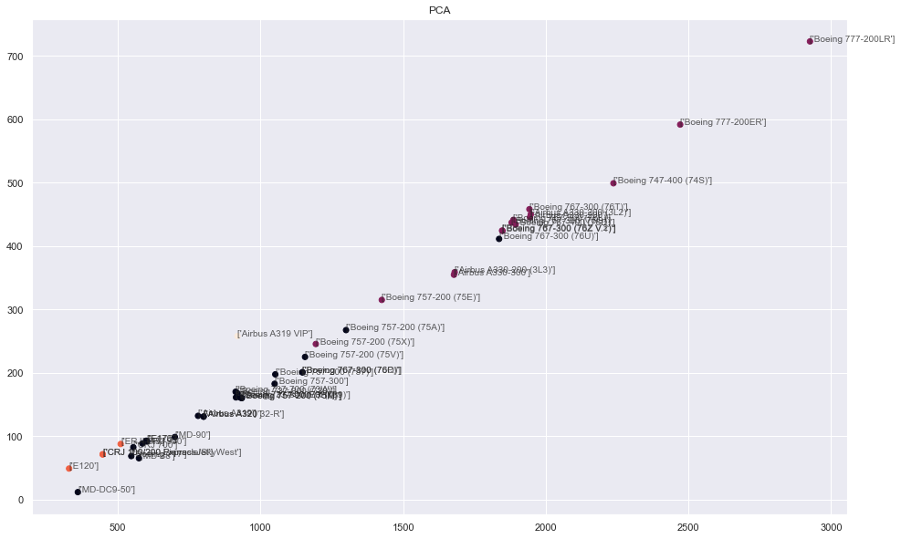

```python
plt.figure(figsize=(16,10))

plt.scatter(reduced_comparison['p1'], reduced_comparison['p2'], c = reduced_comparison['k_clusters'])

# Annotate the points
for x, y, name in zip(reduced_comparison['p1'], reduced_comparison['p2'], aircraft.values):
    plt.annotate(name, (x, y), fontsize=10, alpha=0.75)

plt.title('PCA')
plt.show()
```

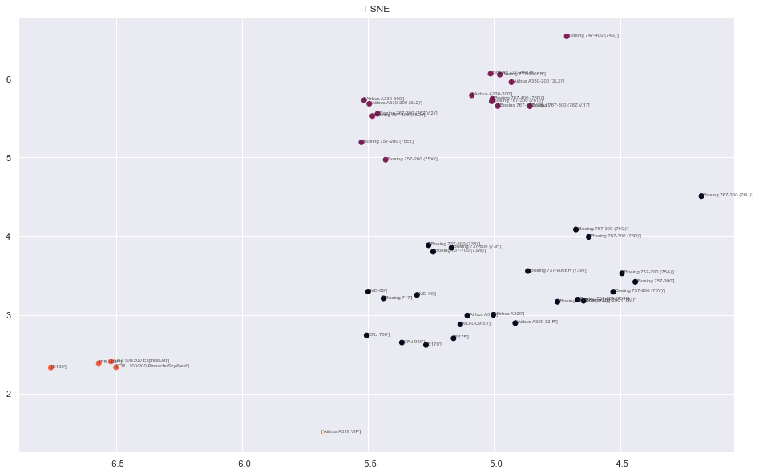

```python
plt.figure(figsize=(16,10))
plt.scatter(reduced_comparison['t1'], reduced_comparison['t2'], c = reduced_comparison['k_clusters'])


#Annotate the points
for x, y, name in zip(reduced_comparison['t1'], reduced_comparison['t2'], aircraft.values):
    plt.annotate(name, (x, y), fontsize=6, alpha=0.75)

plt.title('T-SNE')
plt.show()
```

**4.4 Observation and interpretation**

Both the shape and distribution of the datapoints are very different between the two scatterplots shown above, The value range of two dimensions also varies greatly. The data points almost form a line in PCA, whereas in T-SNE, we can see different colored clusters quite clearly. It shows that PCA, which reduces the dimensionality of data that is highly correlated, does not work well as compared to t-SNE, which aims to preserve the neighborhood of each point.

### Problem 5 (Bonus)

Apply Hiearchical Clustering to delta.csv and observe how physical features are being clustered in ealry leaves at the bottom. Please submit your code and dendrogram graph along with 1-2 sentences interpretation.

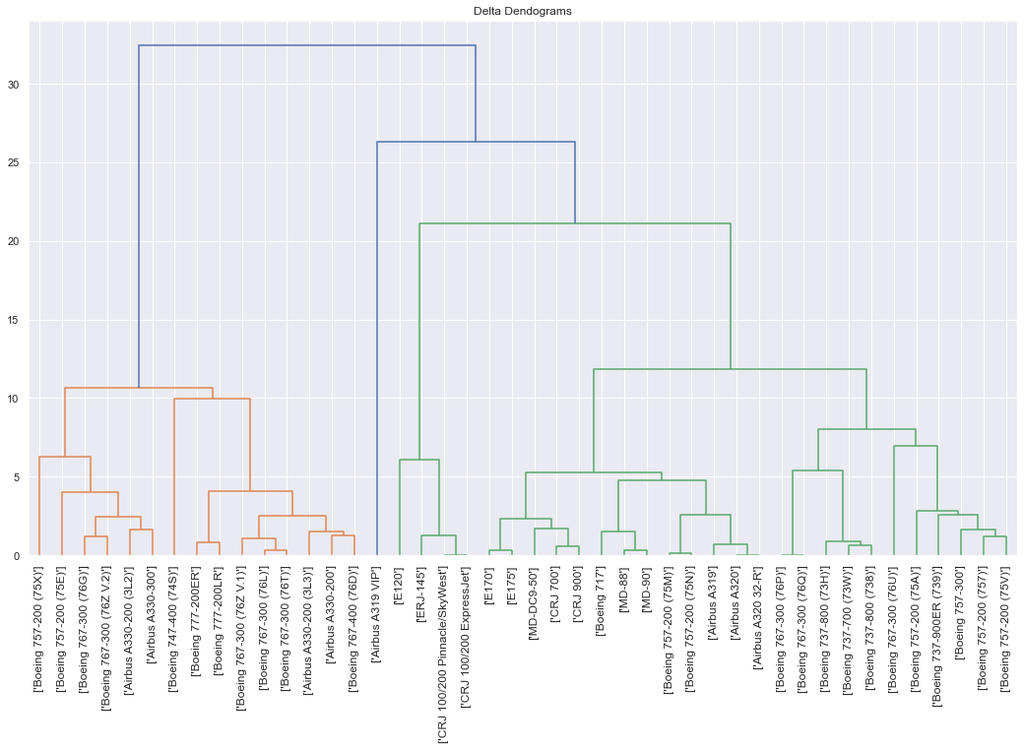

```python
from scipy.cluster.hierarchy import linkage, dendrogram

plt.figure(figsize=(18, 10))
plt.title("Delta Dendograms")
mergings = linkage(stdscaled_delta, method='ward')#ward)
dendrogram(mergings, leaf_rotation=90, labels = aircrafttype, leaf_font_size=12)
plt.show()
```

```python
physical_characteristics = ['Cruising Speed (mph)', 'Range (miles)', 'Engines','Wingspan (ft)', 'Tail Height (ft)', 'Length (ft)']
delta.index = aircrafttype
delta.loc[:,physical_characteristics]
```

|  | Cruising Speed (mph) | Range (miles) | Engines | Wingspan (ft) | Tail Height (ft) | Length (ft) |
| --- | --- | --- | --- | --- | --- | --- |
| (Airbus A319,) | 517 | 2399 | 2 | 111.830 | 38.5830 | 111.000 |
| (Airbus A319 VIP,) | 517 | 3119 | 2 | 111.830 | 38.5830 | 111.000 |
| (Airbus A320,) | 517 | 2420 | 2 | 111.830 | 38.5830 | 123.250 |
| (Airbus A320 32-R,) | 517 | 2420 | 2 | 111.830 | 38.5830 | 123.250 |
| (Airbus A330-200,) | 531 | 6536 | 2 | 197.830 | 59.8300 | 188.670 |
| (Airbus A330-200 (3L2),) | 531 | 6536 | 2 | 197.830 | 59.8300 | 188.670 |
| (Airbus A330-200 (3L3),) | 531 | 5343 | 2 | 197.830 | 56.3300 | 208.830 |
| (Airbus A330-300,) | 531 | 5343 | 2 | 197.830 | 56.3300 | 208.830 |
| (Boeing 717,) | 504 | 1510 | 2 | 93.330 | 29.0830 | 120.000 |
| (Boeing 737-700 (73W),) | 517 | 2925 | 2 | 117.416 | 41.1670 | 110.330 |
| (Boeing 737-800 (738),) | 517 | 2925 | 2 | 117.416 | 41.1670 | 110.330 |
| (Boeing 737-800 (73H),) | 517 | 2850 | 2 | 117.416 | 41.1670 | 129.500 |
| (Boeing 737-900ER (739),) | 517 | 2870 | 2 | 117.416 | 41.1670 | 138.167 |
| (Boeing 747-400 (74S),) | 564 | 7365 | 4 | 213.000 | 62.5416 | 231.830 |
| (Boeing 757-200 (75A),) | 517 | 4344 | 2 | 134.750 | 44.5000 | 155.250 |
| (Boeing 757-200 (75E),) | 517 | 4705 | 2 | 134.750 | 44.5000 | 155.250 |
| (Boeing 757-200 (75M),) | 517 | 2854 | 2 | 134.750 | 44.5000 | 155.250 |
| (Boeing 757-200 (75N),) | 517 | 2854 | 2 | 134.750 | 44.5000 | 155.250 |
| (Boeing 757-200 (757),) | 517 | 3393 | 2 | 111.830 | 38.5830 | 123.250 |
| (Boeing 757-200 (75V),) | 517 | 3764 | 2 | 134.750 | 44.5000 | 155.250 |
| (Boeing 757-200 (75X),) | 517 | 3764 | 2 | 134.750 | 44.5000 | 155.250 |
| (Boeing 757-300,) | 517 | 3228 | 2 | 124.830 | 45.0830 | 177.416 |
| (Boeing 767-300 (76G),) | 517 | 6408 | 2 | 156.083 | 52.0000 | 180.250 |
| (Boeing 767-300 (76L),) | 517 | 6408 | 2 | 156.083 | 52.0000 | 180.250 |
| (Boeing 767-300 (76P),) | 517 | 3515 | 2 | 156.083 | 52.0000 | 180.250 |
| (Boeing 767-300 (76Q),) | 517 | 3515 | 2 | 156.083 | 52.0000 | 180.250 |
| (Boeing 767-300 (76T),) | 517 | 6640 | 2 | 156.083 | 52.0000 | 180.250 |
| (Boeing 767-300 (76U),) | 517 | 6408 | 2 | 156.083 | 52.0000 | 180.250 |
| (Boeing 767-300 (76Z V.1),) | 517 | 6221 | 2 | 156.083 | 52.0000 | 180.250 |
| (Boeing 767-300 (76Z V.2),) | 517 | 6221 | 2 | 156.083 | 52.0000 | 180.250 |
| (Boeing 767-400 (76D),) | 517 | 6336 | 2 | 171.000 | 54.9170 | 201.330 |
| (Boeing 777-200ER,) | 550 | 8542 | 2 | 212.583 | 61.3300 | 209.083 |
| (Boeing 777-200LR,) | 550 | 10375 | 2 | 212.583 | 61.3300 | 209.083 |
| (CRJ 100/200 Pinnacle/SkyWest,) | 488 | 1265 | 2 | 69.583 | 20.4160 | 87.830 |
| (CRJ 100/200 ExpressJet,) | 488 | 1265 | 2 | 69.583 | 20.4160 | 87.830 |
| (CRJ 700,) | 515 | 1650 | 2 | 76.250 | 24.8300 | 106.083 |
| (CRJ 900,) | 515 | 1744 | 2 | 81.583 | 24.5830 | 118.916 |
| (E120,) | 364 | 920 | 2 | 64.916 | 20.8300 | 65.583 |
| (E170,) | 545 | 1800 | 2 | 85.416 | 32.3300 | 98.083 |
| (E175,) | 545 | 1800 | 2 | 85.416 | 31.9160 | 103.916 |
| (ERJ-145,) | 517 | 1496 | 2 | 65.750 | 22.1670 | 98.000 |
| (MD-88,) | 498 | 1510 | 2 | 107.830 | 30.5000 | 147.830 |
| (MD-90,) | 498 | 1992 | 2 | 107.830 | 30.5830 | 152.583 |
| (MD-DC9-50,) | 504 | 731 | 2 | 93.830 | 27.5000 | 133.500 |

**Interpretation**

In early leaves at the bottom of the dendrogram, we can observe that same aircraft series number (regardless of their variations) are being clustered together first. If we take a closer look at the relationship of different aircraft series and their respective physical characteristics (6 variables), we can see that same aircraft series tend to have very similar physical characteristics, in other words, the 6 physical features have great impact on early clustering.